# Public Opinion

POLS 2311: Government of the United States

## Agenda

- Define *public opinion* and how it is measured
- Understand the role of *political socialization*
- Understand *political ideology*, partisanship, and polarization
- Know the major demographic divides in American opinion

# The Midterm Elections

## Midterms

- Where we stand
  - **House**: Republicans: 220 and Democrats: 215 (**218** for majority)
  - **Senate**: Republicans: 53 and Democrats: 47
- Outcomes
  - Dems win House, Reps keep Senate (close Senate elections)
  - Dems win House and Senate (close Senate elections)
  - Dems win big

## Senate

**Flips**

- **North Carolina to Dems**
- Michigan to Reps

**Toss ups**

- Maine
- Alaska
- Ohio
- *Texas*

**Stretch**

- Kansas
- Iowa
- Nebraska
- South Carolina

# Can We Trust the Polls?

## Election Polls

- Polls are a snapshot
- Margin of error
- Polls are based on a *sample* of a *population*
  - Surveys of residents of a country, region, state
  - Surveys of registered voters
  - *Elections*:
    - Dynamic
    - Hard to know the right “population”

# Public Opinion

## What is Public Opinion?

- *Public opinion is a collection of popular views about something, perhaps a person, a local or national event, or a new idea*
- Public opinion about politics are related to our:
  - **Beliefs**: closely held ideas that support our values and expectations about life and politics
  - **Attitudes**: the preferences we form based on our life experiences and values

## How Do We Measure Public Opinion?

- **Random Sampling**: A method of selecting from a population in which each person has an equal probability of being selected
- **Sampling error**: the difference between the results of random samples taken at the same time
  - The *margin of error* is how pollsters report the size of the expected sampling error

## How Do We Measure Public Opinion?

- **Margin of error**: how close a poll’s result is likely to be to the true value in the whole population
  - *if a candidate polls at 48% with a margin of error of ±3 points at the 95% confidence level, their real support is probably between 45% and 51%*
- **Nonresponse bias**: if certain groups systematically avoid surveys, the poll can mislead

## Asking the Question

- **Question wording**: the specific phrasing used to describe a policy
  - Simplistic wording misses nuance — Americans’ abortion views are complex, not yes/no
- **Item order** can change the answers people give
- Best practice: compare a poll against other high-quality polls from the same period

## Should We Trust the Polls?

- Real limits: most people have limited knowledge of government and policy
- And yet — citizens generally manage to find candidates and policies that match their values
- Polls are informative in the **aggregate** even when any one respondent is poorly informed

# Is public opinion important?

# Where do your political opinions come from?

# Political Socialization

## What is Political Socialization?

- *The process of learning the norms and practices of a political system through others and societal institutions*
- **Agent of political socialization**
  - Parents
  - Education
  - Media
  - Community
  - Events

## Socialization: Stability and Change

- Socialization produces **stable** orientations — party ID and basic values usually form early and last
- *Only events that significantly affect an individual tend to alter fundamental beliefs and attitudes*
- **Generational imprinting**: coming of age during a major event (the Depression, Watergate, 9/11, the Great Recession) leaves a lasting political stamp on a cohort

# Political Ideology

## Political Ideology

- **Political Ideology**: A coherent, organized set of ideas and principles that functions as a core on which individuals draw when forming their attitudes about public affairs
  - The attitudes and beliefs that help shape our opinions on political theory and policy

## Political Ideology

- *Political ideology is not static*
  - *… but only events that significantly affect an individual tend to alter fundamental beliefs and attitudes*
  - The difficulty in changing underlying attitudes and beliefs fosters **political polarization**

## Political Ideology: Left-Right Spectrum

[figure not shown]

## Political Ideology

### Conservative vs. Liberal

- *Role of government in society*
- Pace of change
- Social vs. Economic

## Political Ideology

[figure not shown]

# Demographic Divides in Opinion

## Beyond Party and Ideology

- Opinion also splits along measurable demographic lines:
  - Gender
  - Race and ethnicity
  - Religion
  - Age
  - Education

## The Gender Gap

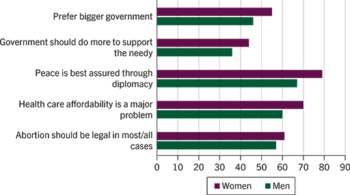

## Race and Ethnicity

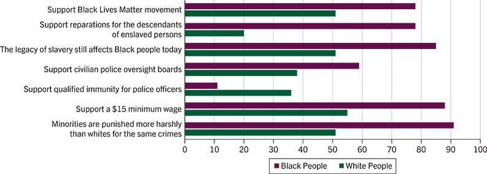

## Latino Opinion

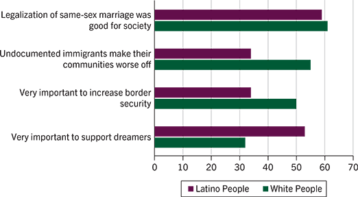

## Age

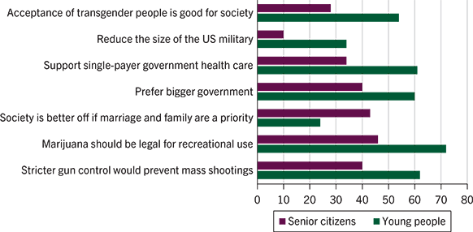

## Education

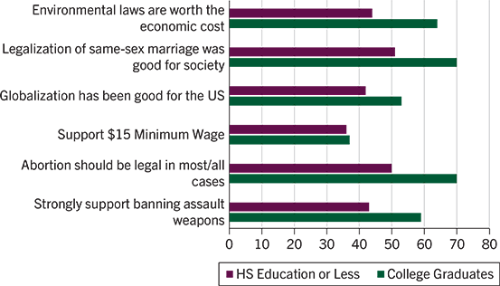

## Religion

- More religious Americans are more likely to oppose abortion and same-sex marriage, and are more conservative overall
- The divide tracks **religiosity** (how often you attend, how important faith is) more than **denomination**

# Partisanship and Polarization

## Partisanship

- **Partisanship**: A long-term, stable psychological attachment to a political party
- After family, **partisanship and ideology are the largest influence on opinion**
- Partisanship works as a **perceptual screen**: partisans take cues from their own party’s leaders and reject the other side’s
  - Even factual judgments — like how the economy is doing — shift with which party holds the White House

## Growing Ideological Consistency

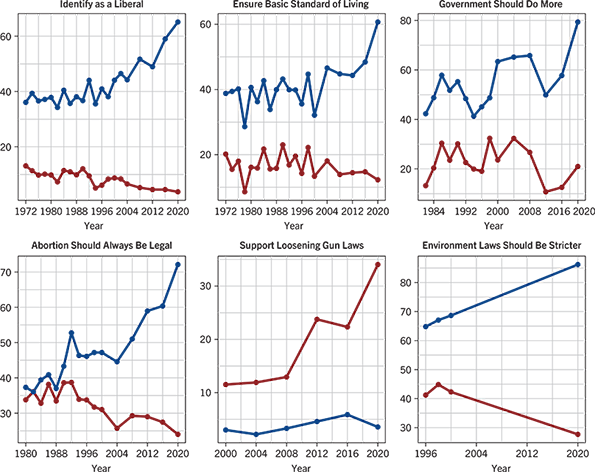

## Two Kinds of Polarization

- **Issue (ideological) polarization**: partisans move apart on *policy positions* — real, but its size for the mass public is debated
- **Affective polarization**: partisans increasingly *dislike and distrust* the other side as people
  - Measured with “feeling thermometers”
  - Has risen sharply even when policy views have not

# How Much Do Voters Know?

## The Political Knowledge Debate

- Decades of surveys: most people know little about government, policy, or who is responsible for what — and knowledge has not risen despite more schooling
- **Rational ignorance**: one vote almost never decides an election, so studying the details is a poor use of time
- Optimists’ reply: **information shortcuts** (party labels, endorsements) and the **“miracle of aggregation”** (random errors cancel out)

## Do the Shortcuts Work?

- Critics: the shortcuts have limits
  - **Retrospective voting** still needs background knowledge — voters punish incumbents for droughts, even local sports losses
  - Aggregation only cancels *random* error; **systematic** misperceptions do not cancel
- The politically engaged minority are often “political fans” — prone to motivated reasoning and selective exposure

# Public Opinion and Public Policy

## Does Opinion Shape Policy?

- Usually, yes — **when opinion moves left (right), policy tends to follow left (right)**
- But policy does not always track the majority’s will:
  - Politicians respond to the **organized, intense minority** over the apathetic majority
  - Policy *may* track the **economic elite** more closely than the median voter

## The Public as Thermostat

- Opinion also responds **to** policy: the public adjusts its preferences when policy moves away from what it wants
- **Thermostatic response**: when government spends more on a program, the public wants *less*; when spending falls, demand for more rises
  - Example: support for more defense spending fell after the Reagan-era buildup
- **Policy mood** swings against the party in power — the public tends to move left under Republican presidents and right under Democratic ones
- The result: opinion and policy correct each other in a feedback loop